[figure not shown]

# La Distribución Normal

Despues de haber hablado de las distribuciones de probabilidad es propicio que nos introduzcamos a la que tal vez sea la distribución de probabilidad continua más importante en todo el campo de la estadística, esta distribución se llama *“normal”* porque aparece en muchos contextos del mundo real, tambien se le conoce como **Distribución Gaussiana** esto en honor a Karl Friedrich Gauss, quien derivó su ecuación de un estudio de errores en mediciones repetidas de la misma cantidad. La ecuación que Gauss hallo es la **Función de Densidad de Probabilidad (PDF)** (denotada por $f$) que se expresa como sigue a continuación:

$$f(x; \mu,\sigma)=\frac{1}{\sigma\sqrt{2\pi}}e^{-\frac{1}{2}(\frac{x-\mu}{\sigma})^2}$$

Donde $\mu$ es la media y $\sigma$ la desviación estándar de el espacio muestral $\overline{X}$. Esta distribución surgira si en nuestros la media $\mu$, mediana y moda son similares o directamente iguales. La curva que describe dicha función es una curva *simétrica* (con respecto a su eje central que se encuentra justamente en la media) y *mesocúrtica* (o sea que su punta no es ni plana ni puntiaguda), donde además la desviación estándar $\sigma$ representa la *curvaturva*; una gráfica siempre similar a esta:

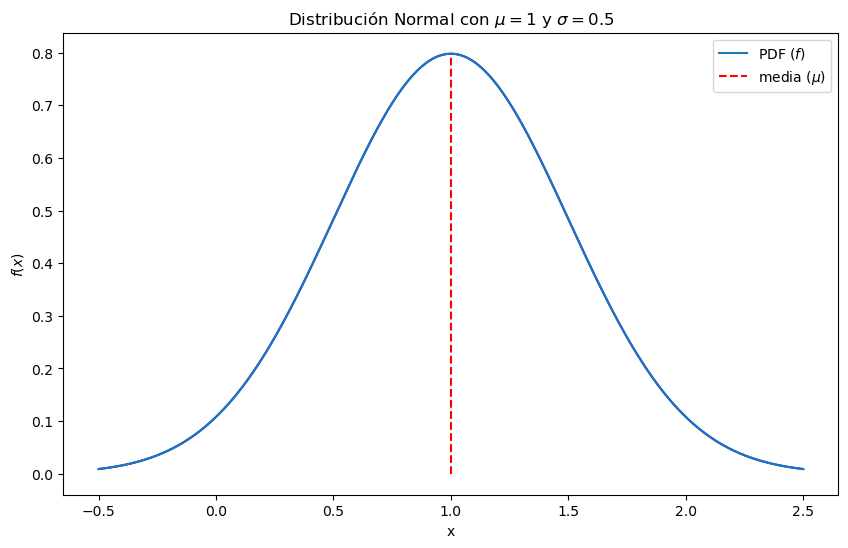

```python
# Importemos todos los paquetes necesarios:
import numpy as np
import matplotlib.pyplot as plt
import seaborn as sns
from scipy.stats import norm

# Supongamos que nuestra PDF tiene media 1 y desviación estándar 1/2:
mu = 1
sigma = 0.5

# Definimos los rangos en los cuales el rango en el cual los valores de f(x) son significativos:
x = np.linspace(mu - 3*sigma, mu + 3*sigma, 1000)

# Utilizamos Scipy para generar la función f (eto lo explicare más adelante):
f_x = norm.pdf(x, mu, sigma)

# Crear la gráfica:
plt.figure(figsize=(10, 6))

# Utilizar Seaborn para hacer la gráfica más estética:
sns.lineplot(x=x, y=f_x, color='blue')

# Denotar la curva como f(x):
plt.plot(x, f_x, label='PDF $(f)$')

# Calcular el valor de f(1) (el PDF lo explicare más adelante):
f_1 = norm.pdf(mu, mu, sigma)

# Dibujar el segmento desde (1,0) a (1,f(1)):
plt.plot([mu, mu], [0, f_1], color='red', linestyle='--', label='media $(\mu)$')
plt.legend()

# Añadir títulos y etiquetas de los ejes:
plt.title('Distribución Normal con $\mu = 1$ y $\sigma = 0.5$')
plt.xlabel('x')
plt.ylabel('$f(x)$')

# Mostrar la gráfica
plt.show()
```

### Características de la Curva Normal.

- Es *asintótica* en el eje horizontal cuando se desplaza en cualquier direccion $(-\infty, \infty)$.
- Tiene sus *puntos de inflexión* en $x=\mu\pm\sigma$, lo que significa que sera *cóncava* hacia abajo si $\mu-\sigma<x<\mu+\sigma$, y cóncava hacia arriba en cualquier otro caso.
- El rango sobre el eje horizontal que definimos esta medido en una **Unidad Tipificada** donde el marco de referencia es la distancia a la media $\mu$, por ejemplo, si el rango es $\mu+2\sigma$ esto significa que toma todos los valores que se encuentran a $2$ sigmas $\sigma$ de distancia de la media $\mu$.
- Si la distribución normal posee media nula $\mu=0$ y **Varianza** igual a uno $\sigma^2=1$, esta se conocerá como **Distribución Normal Estándar**.

## CDF y PPF de la Distribución Normal.

Ya conociendo que es la distribución Gaussiana lo siguiente que podriamos preguntarnos ¿cómo utilizarla?, para ello, introduciremos $2$ funciones que se definen para todas las distribuciones de probabilidad:

La primera es la **Función de Distribución Acumulativa (CDF)** la cual se utiliza para calcular la probabilidad correspondiente a un intervalo dado (recordemos que la normal es una distribución continua), dicha función se denota por $F$ y es expresa como sigue:

$$\begin{align}
P(a<X<b) &= F(x;a,b) \\
&= \int_{a}^{b}f(x)dx \\
&= \int_{a}^{b}\frac{1}{\sigma\sqrt{2\pi}}e^{\frac{-1}{2}(\frac{x-\mu}{\sigma})^2}dx.
\end{align}$$

Tristemente, la función $f$ no posee una función antiderivada elemental como tal, asi que deberemos aproximarla, bien por métodos numéricos (a travez de la *Función Error de Gauss* $\DeclareMathOperator\erf{erf} \erf(x)$ y su expanción en *Serie de Taylor*) o, de manera más práctica, por medios computacionales. Al ser una integral, la función CDF podra ser interpretada como el área bajo la curva de $f$ y sobre el intervalo $(a,b)$.

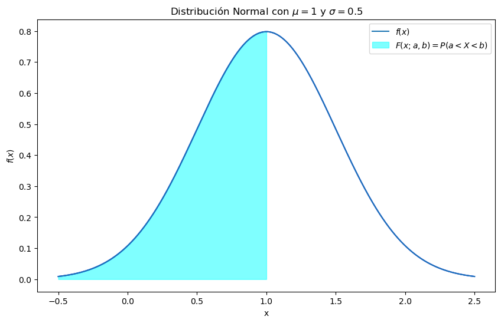

```python
# Crear la gráfica (esto se facilitara por el código anterior):
plt.figure(figsize=(10, 6))

# Utilizar Seaborn para hacer la gráfica más estética:
sns.lineplot(x=x, y=f_x, color='blue')

# Denotar la curva como f(x):
plt.plot(x, f_x, label='$f(x)$')

# Definir los límites de la región a sombrear:
a, b = -0.5, 1

# Sombrear la región bajo la curva entre a y b
x_fill = np.linspace(a, b, 1000)
y_fill = norm.pdf(x_fill, mu, sigma)
plt.fill_between(x_fill, y_fill, color='cyan', alpha=0.5, label=r'$F(x;a,b)=P(a<X<b)$')

# Añadir las etiquetas y la leyenda
plt.legend()

# Añadir títulos y etiquetas de los ejes
plt.title('Distribución Normal con $\mu = 1$ y $\sigma = 0.5$')
plt.xlabel('x')
plt.ylabel('$f(x)$')

# Mostrar la gráfica
plt.show()
```

La segunda, se trata de **La Función Punto de Probabilidad (PPF)**, determina el valor $x_0$ correspondiente a una probabilidad dada $P$. En otras palabras, para una probabilidad $P$ específica, la PPF encuentra el valor $x_0$ tal que el área bajo la curva de la función de densidad de probabilidad en el intervalo $(-\infty,x_0)$ es igual a $P$. Esto es más comprensible gráficamente:

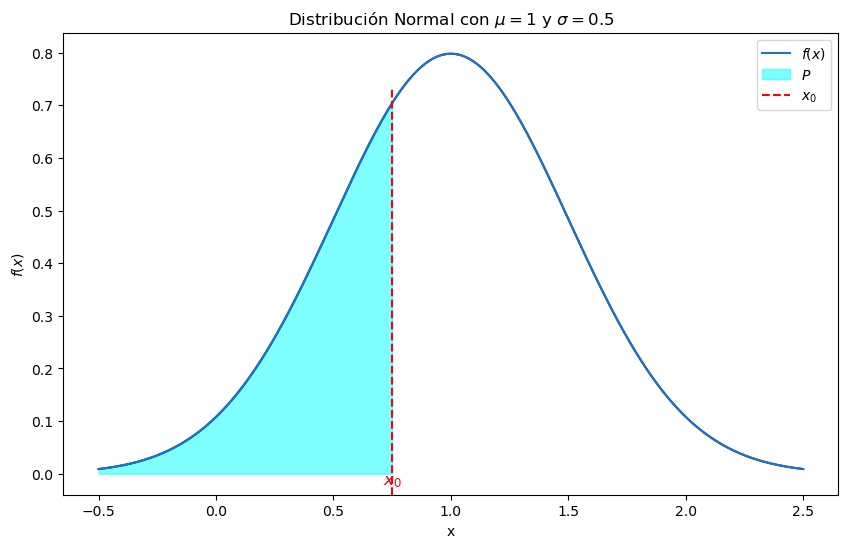

```python
# Crear la gráfica
plt.figure(figsize=(10, 6))

# Utilizar Seaborn para hacer la gráfica más estética
sns.lineplot(x=x, y=f_x, color='blue')

# Denotar la curva como f(x)
plt.plot(x, f_x, label='$f(x)$')

# Definir los límites de la región a sombrear
a, b = -0.5, 0.75

# Sombrear la región bajo la curva entre a y b
x_fill = np.linspace(a, b, 1000)
y_fill = norm.pdf(x_fill, mu, sigma)
plt.fill_between(x_fill, y_fill, color='cyan', alpha=0.5, label=r'$P$')

# Añadir anotación en el punto x=b (denotado como x0)
plt.axvline(b, color='red', linestyle='--', ymax=norm.pdf(b, mu, sigma)/max(f_x), label='$x_0$')
plt.text(b, -0.02, '$x_0$', fontsize=12, color='red', ha='center')

# Añadir las etiquetas y la leyenda
plt.legend()

# Añadir títulos y etiquetas de los ejes
plt.title('Distribución Normal con $\mu = 1$ y $\sigma = 0.5$')
plt.xlabel('x')
plt.ylabel('$f(x)$')

# Mostrar la gráfica
plt.show()
```

Naturalmente al utilizar de entrada la probabilidad y de salida intervalos, se puede afirmar que la función punto de probabilidad PPF se corresponde con la inversa de la función de distribución acumulativa CDF:

$$F^{-1}[P(X<x_0)]=x_0$$

El problema claro esta, es al momento de calcular intervalos en $2$ partes separadas o en un intervalo que no parta desde $-\infty$, pero esto se puede hacer fácilmente restando, sumando o dividiendo áreas como mostramos en el artículo de **Pruebas de Hipótesis por medio del Valor Crítico**.

## ¿Por qué elegir la Distribución Normal?.

Como mencionamos antes, esta distribución se llama “normal” por lo común que es, al emerger en forma aproximada muchos fenómenos que ocurren en la naturaleza la industria y la investigación. Hay una serie de razones que podemos listar por las cuales esto ocurre:

1. Se adapta bien a datos de los cuales la mayoría se acercan a la tendencia central (comunmente el promedio) y muy pocas son extremadamente altas o bajas (lo que se suele llamar valores *atípicos*).
2. A pesar de ser una distribución para variables aletorias continuas esta es capaz de aproximar las distribuciones discretas más usadas tales como la distribución binomial y distribución de poisson.
3. Las distribuciones estadísticas como la media muestral y la proporción muestral se aproximan bien a la distribución normal cuando el tamaño de la muestra es grande, independientemente de como se distribuye la poblacion de origen.

este último punto es el mas importante y se debe a un teorema estadístico demasiado importante como para no mencionar.

### El Teorema Central de Límite.

El enunciado formal de este teorema es el siguiente:

*Si $\overline{X}$ es la media de una muestra elatoria de tamaño $n$, tomada de una población con media $\mu$ y varianza $\sigma^2$, entonces la forma del límite de la distribución de*
$$Z=\frac{\overline{X}-\mu}{\sigma/\sqrt{n}},$$
*a medida que $n\rightarrow\infty$, es la* **Distribución Normal Estándar** $f(z;0,1)$.

Este teorema implica que la distribución de muestreo de la media tendrá (o al menos se aproximara a) una distribución normal, independientemente de la forma de la distribución de la población de la que fue tomada la muestra. Para efectos prácticos, puede suponerse esto puede suponerse siempre que el tamaño de la muestra sea $n\geq30$ (lo cual concordemos se cumple en la mayoría de muestras que tomamos en la vida real).

## Ejemplo.

Uno de los ejemplos más clásicos del uso de la distribución normal es en el estudio de la estatura de las personas. Imaginemos un ejemplo en el cual de una ciudad de $2$ millones de habitantes se quiere inferir información acerca de la altura de los hombres, para ello se extrajo una muestra de $2100$ de personas (en otros artículos se hablara de como extraer y que tamaño deben tener las muestras), de dicha muestra se obtuvo su media $\mu=1.8$ y la varianza $\sigma^2=0.16$.

1. Establezca una distribución que se ajuste a los datos de altura y realice su gráfico de densidad:

Dado que la muestra de datos de altura son mayores a $30$ se puede asumir por TCL que la distribución de muestreo de la media es una distribución normal.

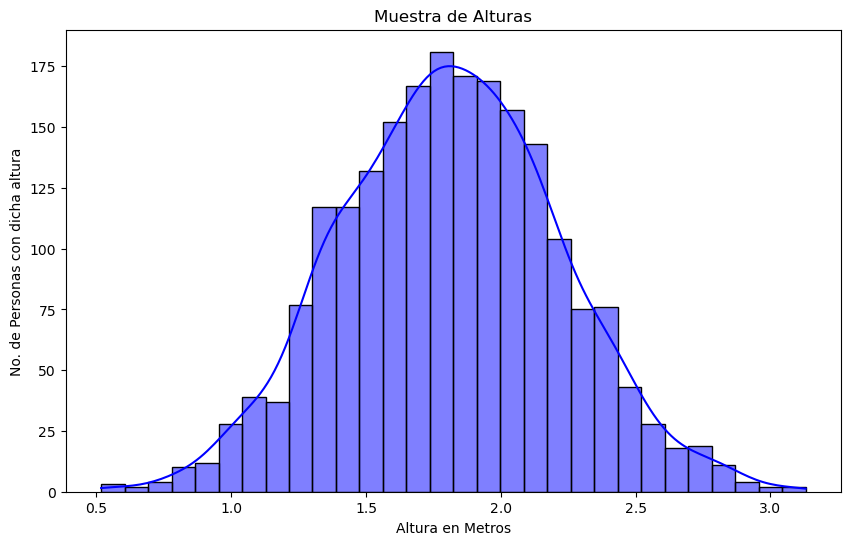

```python
# Dado que no tenemos dicho conjunto de datos, vamos a generarlos aleatoriamente usando NumPy:

# Para ello, primero establezcamos la media y la desviacion estandar:
media = 1.8
varianza = 0.16
dev_sta = np.sqrt(varianza)

# Y ahora si podemos generar los datos:
alturas_muestra = np.random.normal(media, dev_sta, 2100)

# Con lo cual podremos realizar el gráfico de densidad:
plt.figure(figsize=(10, 6))
sns.histplot(alturas_muestra, bins=30, kde=True, color='blue')

plt.title('Muestra de Alturas')
plt.xlabel('Altura en Metros')
plt.ylabel('No. de Personas con dicha altura')

plt.show()
```

calculandolo usando python obtendremos:

```python
# llamaremos a los límites que definen el gigantismo y enanismo x_2 y x_1 respectivamente:
x_1 = abs((2*(dev_sta**2)-media).round(4))
x_2 = abs((2*(dev_sta**2)+media).round(4))

print(f'Una altura por debajo de {x_1} se considera enanismo, una altura por encima de {x_2} se considera gigantismo.')
```

```
Una altura por debajo de 1.48 se considera enanismo, una altura por encima de 2.12 se considera gigantismo.
```

Lo siguiente es usar la función CDF $F$ para calcular la probabilidad de cada una. - En el caso del enanismo es un uso directo del CDF:

$$\begin{align}
\text{Probabilidad de ser enano}&=P(X<x_1)\\
&=F(x_1).
\end{align}$$

- Para el caso del gigantismo podremos calcular su probabilidad de 2 formas distintas, la primera es restandole al área total (que como vimos en las distribuciones de probabilidad siempre es $1$) el área por el lado izquierdo de `x_2` y la segunda implica utiliza el hecho de que curva de la distribución normal es simetrica alrededor de la media, por lo cual, al estar `x_1` y `x_2` a la misma distancia de esta tendriamos que:

$$\begin{align}
\text{Probabilidad de ser gigante}&=P(x_2<X) \\
&=1-F(x_2) \\
&=F(x_1).
\end{align}$$

Para entender esto mejor vease la siguiente gráfica:

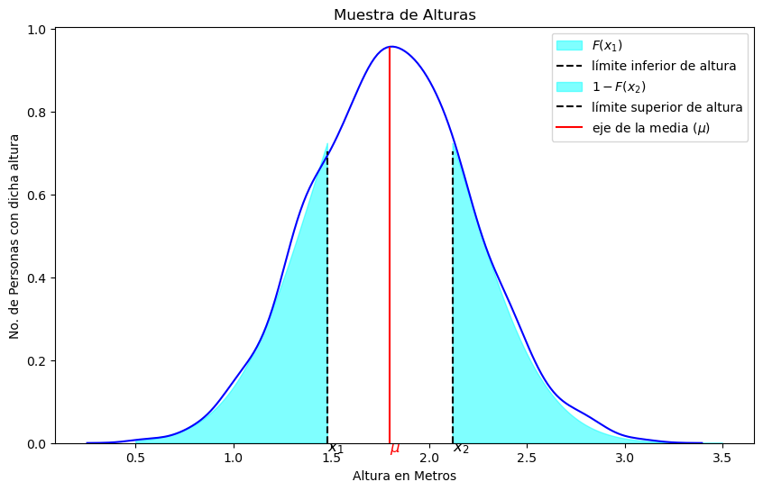

```python
# Crear la gráfica:
plt.figure(figsize=(10, 6))
sns.kdeplot(alturas_muestra, color='blue')

# Área bajo la curva entre 0 y x_1:
x_fill_1 = np.linspace(0.5, x_1, 2100)
y_fill_1 = norm.pdf(x_fill_1, media, dev_sta)
plt.fill_between(x_fill_1, y_fill_1, color='cyan', alpha=0.5, label=r'$F(x_1)$')

# Recta de x_1:
plt.axvline(x_1, color='black', linestyle='--', ymax=0.7, label='límite inferior de altura')
plt.text(x_1, -0.02, '$x_1$', fontsize=12, color='black', ha='left')

# Área bajo la curva entre x_2 y 3.5:
x_fill_2 = np.linspace(x_2, 3.5, 2100)
y_fill_2 = norm.pdf(x_fill_2, media, dev_sta)
plt.fill_between(x_fill_2, y_fill_2, color='cyan', alpha=0.5, label=r'$1-F(x_2)$')

# Recta de x_2:
plt.axvline(x_2, color='black', linestyle='--', ymax=0.7, label='límite superior de altura')
plt.text(x_2, -0.02, '$x_2$', fontsize=12, color='black', ha='left')

# Recta de la media:
plt.axvline(media, color='red', linestyle='-', ymax=0.95, label=r'eje de la media $(\mu)$')
plt.text(media, -0.02, '$\mu$', fontsize=12, color='red', ha='left')

# Añadir las etiquetas y la leyenda
plt.legend()

# Insertando los correspondientes títulos:
plt.title('Muestra de Alturas')
plt.xlabel('Altura en Metros')
plt.ylabel('No. de Personas con dicha altura')

# Mostrar la gráfica:
plt.show()
```

Ya sabiendo esto, basta con aplicar dicha función CDF, antiguamente, se utilizaba la **función error de Gauss** $\erf()$ y su expansión en series de Taylor para crear tablas con valores aproximados del CDF que se necesitara (tanto asi, que podran encontrar estas tablas en los anexos de los libros que dejo de referencia). Hoy día se puede utilizar lenguajes de programación como Python o R para hacer esto, en el caso específico de Python existen varias formas de hacer esto, una es crear la función desde $0$ y guardarla como una clase o modulo y otra es usar un módulo predefinido ya existente. En nuestro caso haremos esto último, los $2$ más comunmente usados son `SciPy` y `StatsModels`, ambas funcionan de manera muy similar y para lo que las usaremos nos vale cualquiera de ellas.

```python
# Ya que previamente importamos la funcionalidad de SciPy, utilicemos esta:
## Para ello debemos suministrarle a la función la media y desviación estándar
probabilidad_enanismo=probabilidad_gigantismo=(norm.cdf(x_1, loc=media, scale=dev_sta)).round(4)

print(f'tanto la probabilidad de tener gigantismo o enanismo son iguales y equivalen aproximadamente a {probabilidad_enanismo*100}%.')
```

```
tanto la probabilidad de tener gigantismo o enanismo son iguales y equivalen aproximadamente a 21.19%.
```

Al tener un desarrollo más largo y un poco más técnico, las demostraciones de la varianza y la media con $\sigma^2$ y $\mu$ respectivamente, la prueba del teorema central del límite y posiblemente tambien el como aproximar la PDF normal mediante métodos puramente numéricos agregando una nueva sección para quienes esten interesados. Tratare de manera más precisa el como se trabaja con las áreas de probabilidad y la función PPF $(F^{-1})$ en mi artículo sobre las **Pruebas de Hipótesis por medio del Valor Critico**.

Gracias por leer.

## Referencias.

- Devore, Jay L. *Probabilidad y estadística para ingeniería y ciencias*. Novena edición, Pearson, 2011.
- J.Kazmier, Leonard.(1998).*Estadística Aplicada a la Administración y a la Economía*.McGRAW-HILL.
- Walpole, R. E., & Myers, R. H. (1992). *Probabilidad y Estadística* (4ª ed.). McGraw-Hill.
- Nield, Thomas.(2020).*Essential Math for Data Science*. O’Reilly Media.